# MY472 Assignment 2

202274326

November 1, 2023

## Exercise 1

My public repository can be found here: https://github.com/SylviXu/MY472_Assignment2

## Exercise 2

Here I will visualise on a world map the extent of stay-at-home restriction policies in different regions in 2020-2022 and the income support index for the corresponding period.

I use different shades of red fills to indicate the stringency of the stay-at-home policies in different regions, with darker colours illustrating more restrictive policies for the region. On the other hand, I project yellow bubbles onto the map to indicate the income support index for each area, with higher indexes resulting in larger bubbles.

As we can see from the graph, mainland China, which has the darkest colour, consistently implemented the most restrictive stay-at-home policies from 2020 to 2022, with residents more likely to be asked not to leave their houses unless it was essential to do so. The American Continent is generally more balanced, with a slight tightening of restriction in 2021 compared to 2020, but an overall loosening in 2022, with the same lighter red colour as the rest of the continent except for mainland China. This feature indicates that the level of restriction is approaching zero and that the vast majority of residents will be able to travel freely across the region. The overall situation in the Southeast Asia and Africa region is similar to that of the American Continent, where the level of restriction in the policy is first tightened and then liberalised. However, the Europe and Oceania regions show a smooth downward trend in the degree of policy restriction over the three-year period, as the change in the shade of colour in these regions is relatively less pronounced, but generally getting lighter.

In terms of income support, overall the support provided in all regions of the world is positively correlated with the stringency of the stay-at-home policy. But there’s still some specific information that worth noting. From observing the distribution of the bubbles, we can know that although the European region did not have a particularly stringent stay-at-home policy, a larger number of countries in Europe provided income subsidy support during the period, for the region has the highest density of bubbles as can be seen from the figure. North America has a higher number of large diameter bubbles located in the region, demonstrating the stronger income support offered by North American countries. In addition, the general support was also favourable in Asia, with both mainland China, which had the most strict policies, and the surrounding coastal regions supplying a higher level of income assistance (income support data are missing from the map for regions such as Russia, due to the fact that the names and codes of the countries in the source data do not partially correspond to the indicators supplied in the “geonames” package). Nevertheless, only a few countries in Africa gave income support during the pandemic, as the bubbles there were more sparsely distributed.

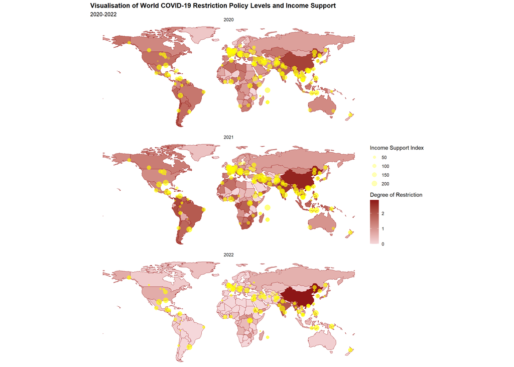

## Exercise 3 Part1

In this part of exercise 3, I will write three functions that develop three types of transformation of strings. The first function is to remove the first character of the input string. The second function is to remove the lowercase letter “a” in the input string. The third function is to remove all the characters between the first character and the last underscore of the input string.

#Function 1: remove the first character.

```r
remove_first_character <- function(input_string) {
  modified_string <- gsub("^.", "", input_string)
  return(modified_string)
}
#Test function 1.
print(list(remove_first_character("apple"),
           remove_first_character("abacus"),
           remove_first_character("Annapolis"),
           remove_first_character("MY472")))
```

```
## [[1]]
## [1] "pple"
##
## [[2]]
## [1] "bacus"
##
## [[3]]
## [1] "nnapolis"
##
## [[4]]
## [1] "Y472"
```

#Function 2: remove the lowercase letter “a”.

```r
remove_character_a <- function(input_string) {
  modified_string <- gsub("a", "", input_string)
  return(modified_string)
}
#Test function 2.
print(list(remove_character_a("apple"),
           remove_character_a("abacus"),
           remove_character_a("Annapolis"),
           remove_character_a("Banana")))
```

```
## [[1]]
## [1] "pple"
##
## [[2]]
## [1] "bcus"
##
## [[3]]
## [1] "Annpolis"
##
## [[4]]
## [1] "Bnn"
```

#Function 3: remove the characters between the first character and the last underscore.

```r
remove_characters_3 <- function(input_string) {
  modified_string <- gsub("^(.).*_(.*?)$", "\\1_\\2", input_string)
  return(modified_string)
}
#Test function 3.
print(list(remove_characters_3("C1_nat_a"),
           remove_characters_3("D2_state_g"),
           remove_characters_3("E_Loc_5_i"),
           remove_characters_3("F_Jazz_6_q")))
```

```
## [[1]]
## [1] "C_a"
##
## [[2]]
## [1] "D_g"
##
## [[3]]
## [1] "E_i"
##
## [[4]]
## [1] "F_q"
```

## Exercise 3 Part2

In this part, I will answer the following question “What is the most common type of crimes mentioned in the Sherlock Holmes novels?” by counting the word frequencies of different crime categories in Conan Doyle’s four works about Holmes. The concepts used here indicating the types of crimes refer to “murder”, “theft”, “blackmail”, “kidnap” and “other”.

Measurement of concepts: “murder”: “murder”, “attempted murder”, “manslaughter”, “homicid”; “theft”: “theft”,“thief”,“thieves”, “steal”, “robbery”; “blackmail”: “blackmail”, “extort”, “extortion”; “kidnap”: “kidnap”, “abduct”, “imprison”; “other”: “treason”, “disloyal”,“counterfeit”.

Here is a preview of my corpus, and the frequency of each type of crimes mentioned in the novels.

```
##                            name characters
## 1            A Study In Scarlet     258683
## 2          The Sign of the Four     251395
## 3 The Hound of the Baskervilles     373431
## 4            The Valley of Fear     331415
```

```
##   Murder Theft Blackmail Kidnap Other
## 1    138    10         8      3     5
```

Obviously, the most common mentioned type of crimes in these novels is Murder, with a prominent frequency of 138.

## Appendix: All code in this assignment

```r
# this chunk contains code that sets global options for the entire .Rmd.
# we use include=FALSE to suppress it from the top of the document, but it will still appear in the appendix.

knitr::opts_chunk$set(echo = FALSE) # actually set the global chunk options.
# we set echo=FALSE to suppress code such that it by default does not appear throughout the document.
# note: this is different from .Rmd default
knitr::opts_chunk$set(warning = FALSE, message = FALSE)

#Open the raw data file.
data <- read.csv("OxCGRT_compact_national_v1.csv")

#Load the packages.
library(ggplot2)
library(rnaturalearth)
library(rnaturalearthdata)
library(dplyr)
library(lubridate)
library(sf)
library(geonames)
library(tidyverse)
library(rworldmap)
library(countrycode)


###Step1: reframe the dataset to a simplified version.--------------------------
Restriction_index <- data %>%
  #Extract essential data needed in this exercise. Here I select the "C6" index to prepare for visualising the level of restriction in the world.
  reframe(CountryCode,
          Date_trans = as.Date(as.character(data$Date), "%Y%m%d"),
          C6M_Stay.at.home.requirements,
          C6M_Flag) %>%
  mutate(Year = year(Date_trans)) %>%
  group_by(CountryCode, Year) %>%
  summarise(Average = mean(C6M_Stay.at.home.requirements)) #By calculating the average of the C6 indicators, the degree of policy constraints in each country/region is derived.
#Transform the reframed data to dataframe for visualisation.
rs <- as.data.frame(Restriction_index)



###Step2: prepare the income support data.--------------------------------------
Eco_support <- data %>%
  #Select "E1" as the main indicator.
  reframe(CountryName,
          CountryCode,
          Date_trans = as.Date(as.character(data$Date), "%Y%m%d"),
          E1_Income.support,
          E1_Flag) %>%
  mutate(Year = year(Date_trans)) %>%
  group_by(CountryName, CountryCode, Year) %>%
  filter(E1_Income.support > 0) %>%  #Here, only nationwide supporting policies are taken into account. Therefore data with "Flag=0" is filtered.
  #Then calculate the weighted average of the income support indicators.
  summarise(Support_index = (sum(E1_Income.support == 2)) *2/3 + (sum(E1_Income.support == 1)) *1/3) %>%
  as.data.frame() %>%
  filter(!is.na(Support_index))



###Step3: Use the "geonames" and "countrycode" packages to extract the coordinates of the world's capitals in preparation for making bubble maps.

#Set up geonames username to access API.
options(geonamesUsername="zhiyant")

#Create a function to get latitude and longitude data for national capitals.
get_capital_coordinates <- function(country_name) {
  country_code <- countrycode(country_name, origin = 'country.name', destination = 'iso3c')
  capital_info <- GNsearch(q = country_code, featureClass = "P", maxRows = 1)
  if (!is.null(capital_info$lat) && !is.null(capital_info$lng)) {
    return(data.frame(country = country_code, latitude = capital_info$lat, longitude = capital_info$lng))
  } else {
    return(NULL)
  }
}

#Use the function created above to extract the coordinates of the capitals of the countries in the dataset.
capital_coordinates <- lapply(Eco_support$CountryName, get_capital_coordinates)
capital_data <- do.call(rbind, capital_coordinates)

#Merge the capital coordinates into the income support table.
merged_eco_data <- merge(Eco_support, capital_data, by.x = "CountryCode", by.y = "country", all.x = TRUE) %>%
  filter(!is.na(Year),
        !is.na(longitude),
        !is.na(latitude))
#Ensure that all data in the dataframe are continuous numeric variables.
merged_eco_data$Support_index <- as.numeric(merged_eco_data$Support_index)
merged_eco_data$latitude <- as.numeric(merged_eco_data$latitude)
merged_eco_data$longitude <- as.numeric(merged_eco_data$longitude)



###Step4: Visualisation---------------------------------------------------------

#Get a map of the world minus Antarctica.
world_map <- ne_countries(returnclass = "sf") %>%
  filter(sov_a3 != "ATA")

#Merge previous collated data with the map data.
plot0 <- merge(world_map, rs, by.x = "iso_a3_eh", by.y = "CountryCode", all.x = TRUE) %>%
  filter(!is.na(Year)) %>%
  ggplot() +
  #Use facet_wrap to facet the plot by year.
  facet_wrap(~Year, ncol = 1) +
  #Fill the map with different shades of red to indicate the level of restriction.
  geom_sf(aes(fill = Average), colour = "darkred")+
  scale_fill_gradient(low = "#f5d7da", high = "#8d1616", name = "Degree of Restriction") +
  #Add bubbles to the map, indicating the level and distribution of income support.
  geom_point(data = merged_eco_data, aes(x = longitude, y = latitude, size = Support_index), color = "yellow", alpha = 0.3) +
  scale_size_continuous(range = c(0.1,5), name = "Income Support Index")+
  #Set the theme features.
  theme_void()+
  theme(plot.title = element_text(face = "bold"),
        legend.position = "right",
        legend.direction = "vertical") +
  labs(title = "Visualisation of World COVID-19 Restriction Policy Levels and Income Support",
       subtitle = "2020-2022",
       x = NULL, y = NULL)

#Preview the final plot.
plot0



remove_first_character <- function(input_string) {
  modified_string <- gsub("^.", "", input_string)
  return(modified_string)
}
#Test function 1.
print(list(remove_first_character("apple"),
           remove_first_character("abacus"),
           remove_first_character("Annapolis"),
           remove_first_character("MY472")))

remove_character_a <- function(input_string) {
  modified_string <- gsub("a", "", input_string)
  return(modified_string)
}
#Test function 2.
print(list(remove_character_a("apple"),
           remove_character_a("abacus"),
           remove_character_a("Annapolis"),
           remove_character_a("Banana")))

remove_characters_3 <- function(input_string) {
  modified_string <- gsub("^(.).*_(.*?)$", "\\1_\\2", input_string)
  return(modified_string)
}
#Test function 3.
print(list(remove_characters_3("C1_nat_a"),
           remove_characters_3("D2_state_g"),
           remove_characters_3("E_Loc_5_i"),
           remove_characters_3("F_Jazz_6_q")))


#Research Question: What are murder crimes mentioned in The Sherlock Holmes novels?
#Load the quanteda library.
library(quanteda)

#Load the book files.
dir_path <- getwd()
book_files <- list.files(dir_path, pattern = "\\.txt$", full.names = TRUE)

#Store text data.
a_study_in_scarlet <- paste(readLines("A Study In Scarlet.txt", warn = FALSE), collapse = "\n")
the_sign_of_the_four <- paste(readLines("The Sign of the Four.txt", warn = FALSE), collapse = "\n")
the_hound_of_the_baskervilles <- paste(readLines("The Hound of the Baskervilles.txt", warn = FALSE), collapse = "\n")
the_valley_of_fear <- paste(readLines("The Valley of Fear.txt", warn = FALSE), collapse = "\n")

my_texts <- c(a_study_in_scarlet, the_sign_of_the_four, the_hound_of_the_baskervilles, the_valley_of_fear)
names(my_texts) <- c("A Study In Scarlet", "The Sign of the Four", "The Hound of the Baskervilles", "The Valley of Fear")

#Build a corpus from the text data.
novel_corpus <- corpus(my_texts,
                       docvars = data.frame(name = names(my_texts),
                                            characters = str_count(my_texts))
)
#Preview the features of the corpus.
docvars(novel_corpus)

#Create a dictionary that contains terms of types of crime.
crime_dictionary <- dictionary(list(
  murder = c("*murder*", "attempted murder", "manslaughter", "homicid"),
  theft = c("theft","thief","thieves", "steal", "robbery"),
  blackmail = c("*blackmail*", "extort*"),
  kidnap = c("kidnap*", "abduct*", "imprison*"),
  other = c("treason", "disloyal*","counterfeit*")))


#Create a document-feature matrix.
dfmplain <- novel_corpus %>%
  tokens(remove_punct = TRUE) %>%
  dfm()

#Count the frequency of words for each type of crime.
count_crime <- dfm_lookup(dfmplain, dictionary = crime_dictionary,
                             valuetype = "glob") %>%
  convert(to = "data.frame") %>%
  summarise(Murder = sum(murder),
            Theft = sum(theft),
            Blackmail = sum(blackmail),
            Kidnap = sum(kidnap),
            Other = sum(other))
count_crime



# this chunk generates the complete code appendix.
# eval=FALSE tells R not to run (``evaluate'') the code here (it was already run before).
```